# Linear Regression using Prostate Data

Disha Deepesh Tandon

2024-09-23

# Linear Regression

Today, we will be using “Prostate Data” that was collected from patients with prostate cancer to create a model that will predict the value of psa based on other features in the data. It has been observed, psa, which is antigen, is elevated in the presence of prostate cancer.

## Setup Chunk

I begin with setting up the environment for the analysis. It loads several useful libraries: ggplot2 (for visualizations), dplyr (for data manipulation), broom (for tidying model outputs), and leaps (for performing regression subset selection). It also suppresses warnings and messages in the output.

## Loading the Data

The chunk below loads the prostate cancer dataset from ProstateData.csv and displays its structure using the str() function. This gives an overview of the variables in the dataset and their data types.

```r
d = read.csv('ProstateData.csv')
str(d)
```

```
## 'data.frame':    97 obs. of  10 variables:
##  $ lcavol : num  -0.58 -0.994 -0.511 -1.204 0.751 ...
##  $ lweight: num  2.77 3.32 2.69 3.28 3.43 ...
##  $ age    : int  50 58 74 58 62 50 64 58 47 63 ...
##  $ lbph   : num  -1.39 -1.39 -1.39 -1.39 -1.39 ...
##  $ svi    : int  0 0 0 0 0 0 0 0 0 0 ...
##  $ lcp    : num  -1.39 -1.39 -1.39 -1.39 -1.39 ...
##  $ gleason: int  6 6 7 6 6 6 6 6 6 6 ...
##  $ pgg45  : int  0 0 20 0 0 0 0 0 0 0 ...
##  $ lpsa   : num  -0.431 -0.163 -0.163 -0.163 0.372 ...
##  $ train  : logi  TRUE TRUE TRUE TRUE TRUE TRUE ...
```

## Converting the svi variable to a Factor

```r
# Calling the dplyr operator with our data
d = d %>%
  mutate(svi = factor(svi, label=c("sviO", "svi1")))
str(d)
```

```
## 'data.frame':    97 obs. of  10 variables:
##  $ lcavol : num  -0.58 -0.994 -0.511 -1.204 0.751 ...
##  $ lweight: num  2.77 3.32 2.69 3.28 3.43 ...
##  $ age    : int  50 58 74 58 62 50 64 58 47 63 ...
##  $ lbph   : num  -1.39 -1.39 -1.39 -1.39 -1.39 ...
##  $ svi    : Factor w/ 2 levels "sviO","svi1": 1 1 1 1 1 1 1 1 1 1 ...
##  $ lcp    : num  -1.39 -1.39 -1.39 -1.39 -1.39 ...
##  $ gleason: int  6 6 7 6 6 6 6 6 6 6 ...
##  $ pgg45  : int  0 0 20 0 0 0 0 0 0 0 ...
##  $ lpsa   : num  -0.431 -0.163 -0.163 -0.163 0.372 ...
##  $ train  : logi  TRUE TRUE TRUE TRUE TRUE TRUE ...
```

The mutate() function from the dplyr package is used to convert the svi variable in the dataset d into a factor. The factor() function assigns two labels: “sviO” and “svi1”, corresponding to the original categories or values in svi. This is an important step because factors are R’s way of dealing with categorical variables, which is useful for modeling or performing categorical data analysis. Following the transformation, the str() function is called to display the updated structure of the dataset, verifying that svi has been successfully converted to a factor with the correct labels. This helps ensure that the variable is properly formatted for further statistical analysis or visualization.

```r
# Check how many levels you have since you turned it to categorical
contrasts(d$svi)
```

```
##      svi1
## sviO    0
## svi1    1
```

I checked the factor levels of svi using contrasts(d$svi) to confirm that the transformation was successful and to view the contrast matrix of the categorical variable.

## Distribution Plot

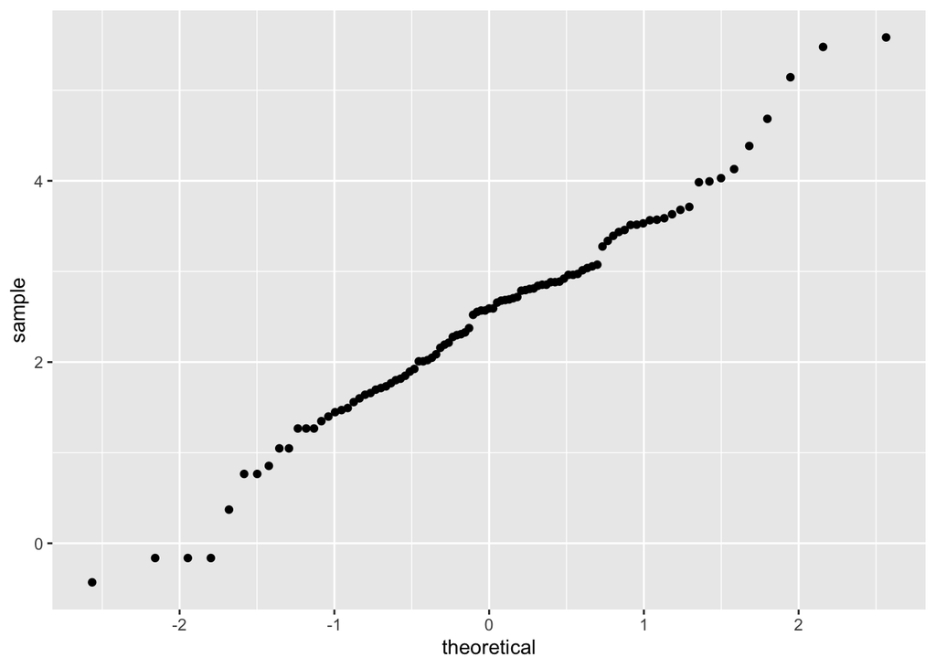

```r
d %>%
  ggplot(aes(sample = lpsa)) +
  geom_qq()
```

I generated a Q-Q plot of lpsa using geom_qq() from ggplot2 to visually assess whether the distribution of lpsa is approximately normal, which is useful for later statistical analyses.

## Correlation Matrix (Excluding svi and train)

Next, let’s look at relationships

```r
d %>%
  select(-svi, -train) %>%
  cor()
```

```
##            lcavol    lweight       age         lbph          lcp    gleason
## lcavol  1.0000000 0.28052138 0.2249999  0.027349703  0.675310484 0.43241706
## lweight 0.2805214 1.00000000 0.3479691  0.442264399  0.164537142 0.05688209
## age     0.2249999 0.34796911 1.0000000  0.350185896  0.127667752 0.26889160
## lbph    0.0273497 0.44226440 0.3501859  1.000000000 -0.006999431 0.07782045
## lcp     0.6753105 0.16453714 0.1276678 -0.006999431  1.000000000 0.51483006
## gleason 0.4324171 0.05688209 0.2688916  0.077820447  0.514830063 1.00000000
## pgg45   0.4336522 0.10735379 0.2761124  0.078460018  0.631528246 0.75190451
## lpsa    0.7344603 0.43331938 0.1695928  0.179809404  0.548813175 0.36898681
##              pgg45      lpsa
## lcavol  0.43365225 0.7344603
## lweight 0.10735379 0.4333194
## age     0.27611245 0.1695928
## lbph    0.07846002 0.1798094
## lcp     0.63152825 0.5488132
## gleason 0.75190451 0.3689868
## pgg45   1.00000000 0.4223159
## lpsa    0.42231586 1.0000000
```

Then,I computed the correlation matrix for the numerical variables in the dataset (excluding svi and train) to explore relationships between the continuous variables and check for multicollinearity.

## Boxplot of svi and lpsa

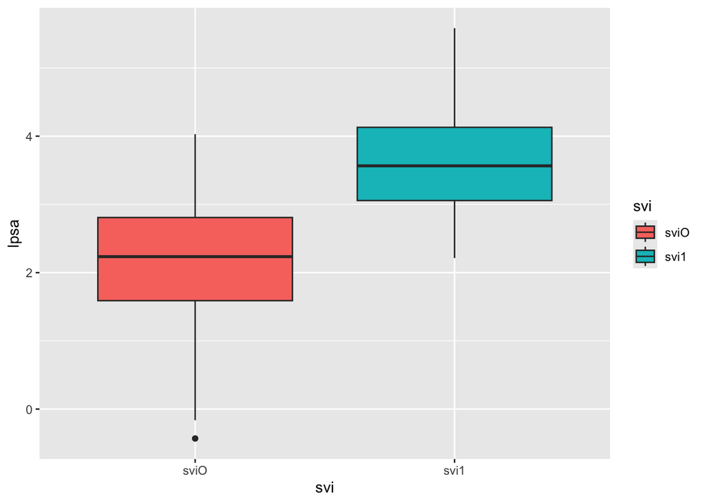

```r
d %>%
  ggplot(aes(x=svi, y=lpsa, fill = svi)) +
  geom_boxplot()
```

Here, I created a boxplot to compare the distribution of lpsa between the two categories of svi. This helps visualize how lpsa varies between these groups, which could suggest a potential relationship.

## Statistical Test: T-Test for lpsa Across svi

```r
library(broom)
d %>%
  do(tidy(t.test(lpsa~svi, data = .))) %>%
  select(p.value)
```

```
## # A tibble: 1 × 1
##        p.value
##          <dbl>
## 1 0.0000000788
```

Next,I performed a t-test to determine whether the mean lpsa differs significantly between the two levels of svi. I use the broom package’s tidy() function to clean the output and extract the p-value to assess the test’s significance.

## Splitting the Dataset into Training and Testing Sets

```r
trainD = d %>%
  filter(train == T) %>%
  select(-train)
testD = d %>%
  filter(train == F) %>%
  select(-train)
```

I split the dataset into training and testing sets using the train variable. This is important for building and evaluating the predictive model. I also remove the train variable after splitting.

## Building a Forward Selection Model

We will begin building a model

```r
library(leaps)

model = regsubsets(lpsa ~ . , data = trainD, method = "forward")
summary(model)
```

```
## Subset selection object
## Call: regsubsets.formula(lpsa ~ ., data = trainD, method = "forward")
## 8 Variables  (and intercept)
##         Forced in Forced out
## lcavol      FALSE      FALSE
## lweight     FALSE      FALSE
## age         FALSE      FALSE
## lbph        FALSE      FALSE
## svisvi1     FALSE      FALSE
## lcp         FALSE      FALSE
## gleason     FALSE      FALSE
## pgg45       FALSE      FALSE
## 1 subsets of each size up to 8
## Selection Algorithm: forward
##          lcavol lweight age lbph svisvi1 lcp gleason pgg45
## 1  ( 1 ) "*"    " "     " " " "  " "     " " " "     " "
## 2  ( 1 ) "*"    "*"     " " " "  " "     " " " "     " "
## 3  ( 1 ) "*"    "*"     " " " "  "*"     " " " "     " "
## 4  ( 1 ) "*"    "*"     " " "*"  "*"     " " " "     " "
## 5  ( 1 ) "*"    "*"     " " "*"  "*"     " " " "     "*"
## 6  ( 1 ) "*"    "*"     " " "*"  "*"     "*" " "     "*"
## 7  ( 1 ) "*"    "*"     "*" "*"  "*"     "*" " "     "*"
## 8  ( 1 ) "*"    "*"     "*" "*"  "*"     "*" "*"     "*"
```

I’m utilizing other factors from the training dataset ‘trainD’ to create a regression model to predict ‘lpsa’. This seeks to determine which predictors have the greatest influence in explaining the variability of ‘lpsa’.

## Difference between Exhaustive and Forward method

The “exhaustive” approach considers every potential subset in order to identify the best one, whereas the “forward” method adds predictors progressively depending on improvements in model fit. Extensive selection ensures optimality but can be computationally costly, whereas forward selection is computationally efficient but may not always discover the ideal subset.

## Viewing Adjusted R-Squared Values for Each Model

```r
# View adjusted R-square value of each model
summary(model)$adjr2
```

```
## [1] 0.5304013 0.6027172 0.6201758 0.6371877 0.6396181 0.6510880 0.6579833
## [8] 0.6522155
```

Furthermore, I extracted the adjusted R-squared values from each model generated during forward selection. Adjusted R-squared helps evaluate how well each model explains the variation in lpsa, while accounting for the number of predictors.

## Viewing Residual Sum of Squares (RSS) for Each Model

```r
# View residual sum of squares value of each model
summary(model)$rss
```

```
## [1] 44.52858 37.09185 34.90775 32.81499 32.06945 30.53978 29.43730 29.42638
```

Then displayed the residual sum of squares (RSS) for each model. RSS measures the total squared difference between observed and predicted values, helping assess the fit of each model.

## Finding the Best Model Based on Adjusted R-Squared

```r
modelSum=summary(model)
which.max(modelSum$adjr2)
```

```
## [1] 7
```

I used which.max() to find the model with the highest adjusted R-squared value, as this model is likely the best at explaining the variance in lpsa.

## Displaying Coefficients of the Best Model

```r
coef(model,which.max(modelSum$adjr2))
```

```
##  (Intercept)       lcavol      lweight          age         lbph      svisvi1
##  0.259061747  0.573930391  0.619208833 -0.019479879  0.144426474  0.741781258
##          lcp        pgg45
## -0.205416986  0.008944996
```

Finally, I retrieved the coefficients of the model that has the highest adjusted R-squared value. These coefficients represent how each predictor influences the outcome variable lpsa, providing insight into the strength and direction of these relationships.